# Project Credit Card

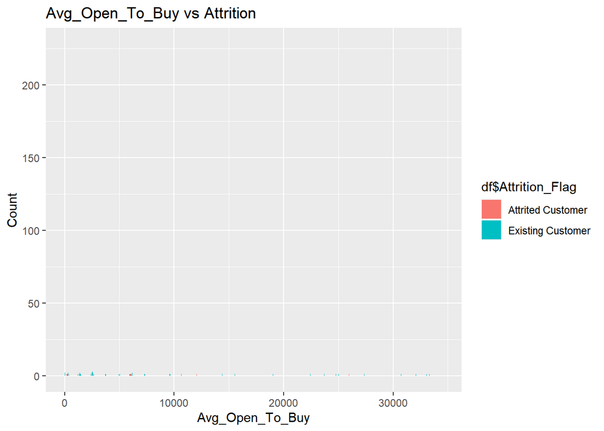

```r
pl14 <-ggplot(data = df,aes(x = df$Avg_Open_To_Buy, fill = df$Attrition_Flag)) + geom_bar(position = position_dodge())+labs(x = "Avg_Open_To_Buy", y = "Count",title = "Avg_Open_To_Buy vs Attrition")
pl14
```

#Total_Trans_Amt Vs Attrition

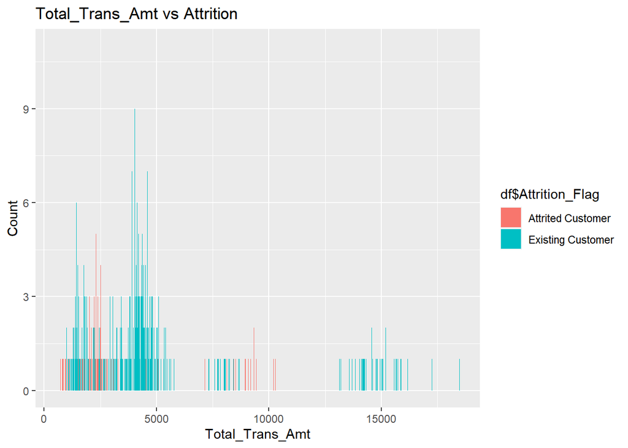

```r
pl15 <-ggplot(data = df,aes(x = df$Total_Trans_Amt, fill = df$Attrition_Flag)) + geom_bar(position = position_dodge())+labs(x = "Total_Trans_Amt", y = "Count",title = "Total_Trans_Amt vs Attrition")
pl15
```

#Total_Trans_Count Vs Attrition

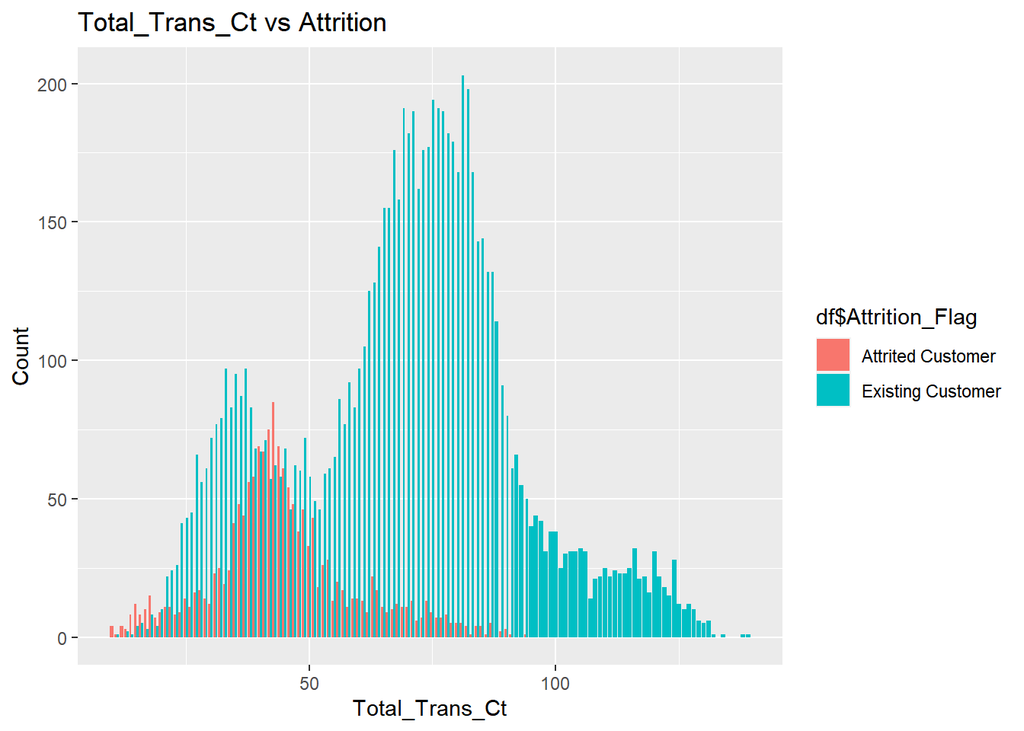

```r
pl16 <-ggplot(data = df,aes(x = df$Total_Trans_Ct, fill = df$Attrition_Flag)) + geom_bar(position = position_dodge())+labs(x = "Total_Trans_Ct", y = "Count",title = "Total_Trans_Ct vs Attrition")
pl16
```

#Avg_Utilization_Ratio Vs Attrition

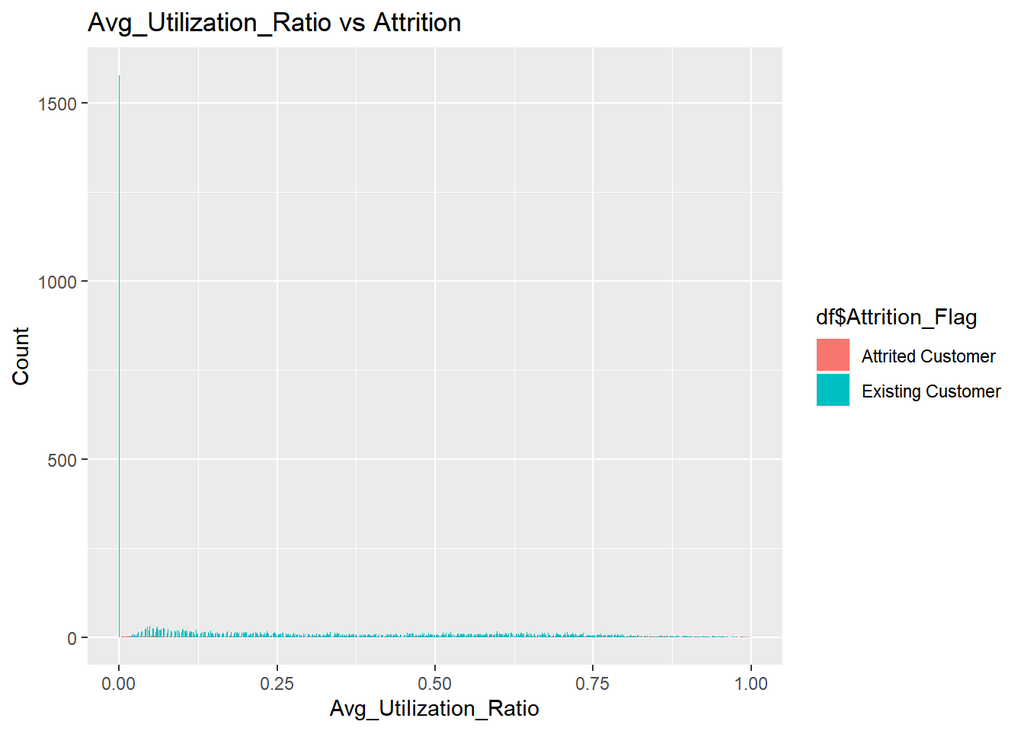

```r
pl17 <-ggplot(data = df,aes(x = df$Avg_Utilization_Ratio, fill = df$Attrition_Flag)) + geom_bar(position = position_dodge())+labs(x = "Avg_Utilization_Ratio", y = "Count",title = "Avg_Utilization_Ratio vs Attrition")
pl17
```

#total Grid of the Vizualizations with the Attrition rate

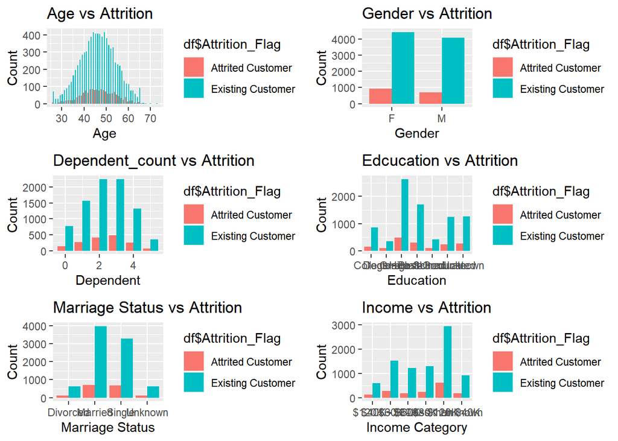

```r
grid.arrange( pl1,pl2,pl3,pl4,pl5,pl6,ncol=2)
```

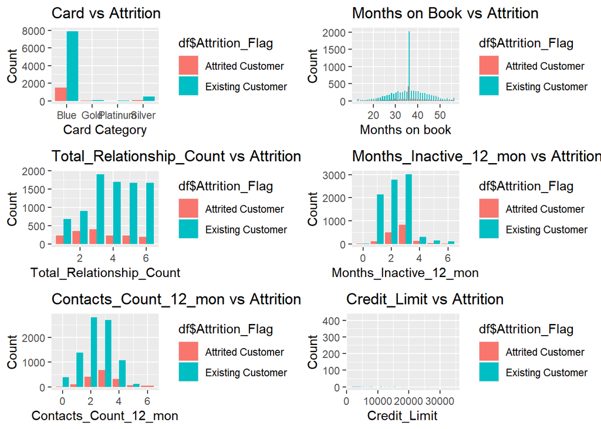

```r
grid.arrange( pl7,pl8,pl9,pl10,pl11,pl12,ncol=2)
```

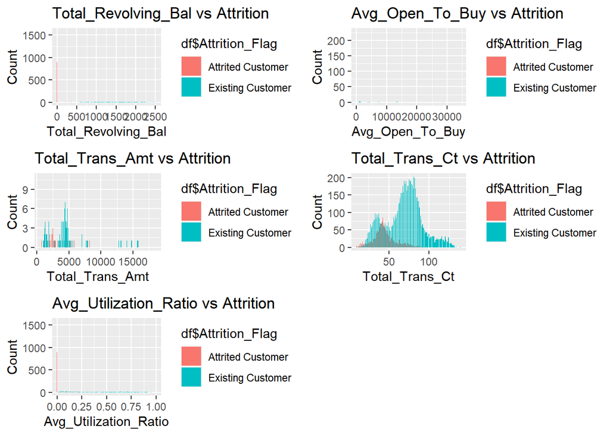

```r
grid.arrange( pl13,pl14,pl15,pl16,pl17,ncol=2)
```

#As we observe that there are certain graphs which are unusual we try plotting the box plots for the numerical variables to identify the outliers

#BOXPLOTS #Plots of the Numerical varibles

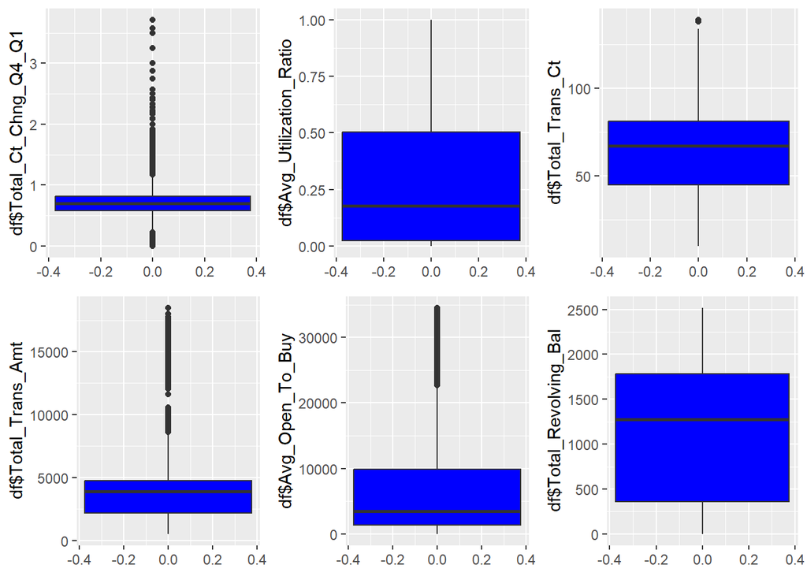

```r
b1=ggplot(df, aes(y =df$Total_Ct_Chng_Q4_Q1)) + geom_boxplot(fill = "blue")
b2=ggplot(df, aes(y =df$Avg_Utilization_Ratio)) + geom_boxplot(fill = "blue")
b3=ggplot(df, aes(y =df$Total_Trans_Ct)) + geom_boxplot(fill = "blue")
b4=ggplot(df, aes(y =df$Total_Trans_Amt)) + geom_boxplot(fill = "blue")

b5=ggplot(df, aes(y =df$Avg_Open_To_Buy)) + geom_boxplot(fill = "blue")
b6=ggplot(df, aes(y =df$Total_Revolving_Bal)) + geom_boxplot(fill = "blue")
b7=ggplot(df, aes(y =df$Credit_Limit)) + geom_boxplot(fill = "blue")
b8=ggplot(df, aes(y =df$Contacts_Count_12_mon)) + geom_boxplot(fill = "blue")

b9=ggplot(df, aes(y =df$Months_Inactive_12_mon)) + geom_boxplot(fill = "blue")
b10=ggplot(df, aes(y =df$Total_Relationship_Count)) + geom_boxplot(fill = "blue")
b11=ggplot(df, aes(y =df$Months_on_book)) + geom_boxplot(fill = "blue")
b12=ggplot(df, aes(y =df$Customer_Age)) + geom_boxplot(fill = "blue")
grid.arrange( b1,b2,b3,b4,b5,b6,ncol=3)
```

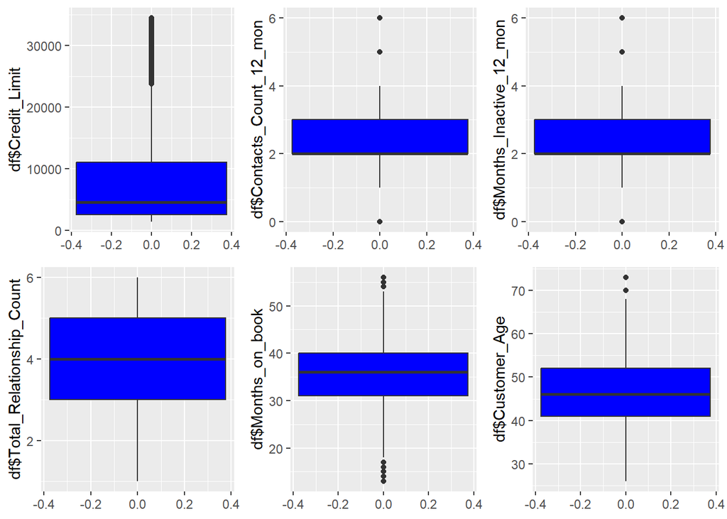

```r
grid.arrange( b7,b8,b9,b10,b11,b12,ncol=3)
```

#caliculation of the Extreme Outliers

```r
Q1_age <- quantile(df$Customer_Age,0.25)
Q3_age <- quantile(df$Customer_Age,0.75)
IQRage <- IQR(df$Customer_Age)
Q1_lowage <- Q1_age - (3*IQRage)
Q3_highage <- Q3_age + (3*IQRage)

sum(table(boxplot.stats(df$Customer_Age)$out))
```

```
## [1] 2
```

#caliculation of months on book

```r
Q1_mob <- quantile(df$Months_on_book,0.25)
Q3_mob <- quantile(df$Months_on_book,0.75)
IQR_mob <- IQR(df$Months_on_book)
Q1_lowmob <- Q1_mob - (3*IQR_mob)
Q3_highmob <- Q3_mob + (3*IQR_mob)

sum(table(boxplot.stats(df$Months_on_book)$out))
```

```
## [1] 386
```

#caliculation of credit limit

```r
Q1_cdr <- quantile(df$Credit_Limit,0.25)
Q3_cdr <- quantile(df$Credit_Limit,0.75)
IQR_cdr <- IQR(df$Credit_Limit)
Q1_lowcdr <- Q1_cdr - (3*IQR_cdr)
Q3_highcdr <- Q3_cdr + (3*IQR_cdr)

sum(table(boxplot.stats(df$Credit_Limit)$out))
```

```
## [1] 984
```

#caliculation of avg open to buy

```r
Q1_opbuy <- quantile(df$Avg_Open_To_Buy,0.25)
Q3_opbuy <- quantile(df$Avg_Open_To_Buy,0.75)
IQR_opbuy <- IQR(df$Avg_Open_To_Buy)
Q1_lowopbuy <- Q1_opbuy- (3*IQR_opbuy)
Q3_highopbuy <- Q3_opbuy + (3*IQR_opbuy)
```

```r
sum(table(boxplot.stats(df$Avg_Open_To_Buy)$out))
```

```
## [1] 963
```

#total trans amt

```r
Q1_tamt <- quantile(df$Total_Trans_Amt,0.25)
Q3_tamt <- quantile(df$Total_Trans_Amt,0.75)
IQR_tamt <- IQR(df$Total_Trans_Amt)
Q1_lowtamt <- Q1_tamt- (3*IQR_tamt)
Q3_hightamt <- Q3_tamt + (3*IQR_tamt)
```

```r
sum(table(boxplot.stats(df$Total_Trans_Amt)$out))
```

```
## [1] 896
```

#total trans count

```r
Q1_tct <- quantile(df$Total_Trans_Ct,0.25)
Q3_tct <- quantile(df$Total_Trans_Ct,0.75)
IQR_tct <- IQR(df$Total_Trans_Ct)
Q1_lowtct <- Q1_tct- (3*IQR_tct)
Q3_hightct <- Q3_tct + (3*IQR_tct)
```

```r
sum(table(boxplot.stats(df$Total_Trans_Ct)$out))
```

```
## [1] 2
```

#total trans count q4 - q1

```r
Q1_ttc <- quantile(df$Total_Ct_Chng_Q4_Q1,0.25)
Q3_ttc <- quantile(df$Total_Ct_Chng_Q4_Q1,0.75)
IQR_ttc <- IQR(df$Total_Ct_Chng_Q4_Q1)
Q1_lowttc <- Q1_ttc- (3*IQR_ttc)
Q3_highttc <- Q3_ttc + (3*IQR_ttc)
```

```r
sum(table(boxplot.stats(df$Total_Ct_Chng_Q4_Q1)$out))
```

```
## [1] 394
```

#Months_Inactive_12_mon

```r
Q1_min <- quantile(df$Months_Inactive_12_mon,0.25)
Q3_min <- quantile(df$Months_Inactive_12_mon,0.75)
IQR_min <- IQR(df$Months_Inactive_12_mon)
Q1_lowmin <- Q1_min- (3*IQR_min)
Q3_highmin <- Q3_min + (3*IQR_min)
```

```r
sum(table(boxplot.stats(df$Months_Inactive_12_mon)$out))
```

```
## [1] 331
```

#Contacts_Count_12_mon

```r
Q1_ccout <- quantile(df$Contacts_Count_12_mon,0.25)
Q3_ccout <- quantile(df$Contacts_Count_12_mon,0.75)
IQR_ccout <- IQR(df$Contacts_Count_12_mon)
Q1_lowccout <- Q1_ccout- (3*IQR_ccout)
Q3_highccout <- Q3_ccout + (3*IQR_ccout)
```

```r
sum(table(boxplot.stats(df$Contacts_Count_12_mon)$out))
```

```
## [1] 629
```

#we have certain outliers that are extreme we will delete the extreme outliers in the data.

```r
df_new <- subset(df, df$Customer_Age > Q1_lowage & df$Customer_Age < Q3_highage)
df_new <- subset(df, df$Months_on_book > Q1_lowmob & df$Months_on_book < Q3_highmob)
df_new <- subset(df, df$Credit_Limit > Q1_lowcdr & df$Credit_Limit < Q3_highcdr)
df_new <- subset(df, df$Avg_Open_To_Buy > Q1_lowopbuy & df$Avg_Open_To_Buy < Q3_highopbuy)
df_new <- subset(df, df$Total_Trans_Amt > Q1_lowtamt & df$Total_Trans_Amt  < Q3_hightamt)
df_new <- subset(df, df$Total_Trans_Ct > Q1_lowtct & df$Total_Trans_Ct < Q3_hightct)
df_new <- subset(df, df$Total_Ct_Chng_Q4_Q1 > Q1_lowttc & df$Total_Ct_Chng_Q4_Q1  < Q3_highttc)
df_new <- subset(df, df$Months_Inactive_12_mon > Q1_lowmin & df$Months_Inactive_12_mon < Q3_highmin)
df_new <- subset(df, df$Contacts_Count_12_mon > Q1_lowccout & df$Months_Inactive_12_mon < Q3_highccout)
```

# after cleaning the extreme outliers we have reduced the observations from 10127 to 10003

#Missing Values

```r
summary(is.na(df_new))
```

```
##  CLIENTNUM       Attrition_Flag  Customer_Age      Gender
##  Mode :logical   Mode :logical   Mode :logical   Mode :logical
##  FALSE:10003     FALSE:10003     FALSE:10003     FALSE:10003
##  Dependent_count Education_Level Marital_Status  Income_Category
##  Mode :logical   Mode :logical   Mode :logical   Mode :logical
##  FALSE:10003     FALSE:10003     FALSE:10003     FALSE:10003
##  Card_Category   Months_on_book  Total_Relationship_Count
##  Mode :logical   Mode :logical   Mode :logical
##  FALSE:10003     FALSE:10003     FALSE:10003
##  Months_Inactive_12_mon Contacts_Count_12_mon Credit_Limit
##  Mode :logical          Mode :logical         Mode :logical
##  FALSE:10003            FALSE:10003           FALSE:10003
##  Total_Revolving_Bal Avg_Open_To_Buy Total_Amt_Chng_Q4_Q1 Total_Trans_Amt
##  Mode :logical       Mode :logical   Mode :logical        Mode :logical
##  FALSE:10003         FALSE:10003     FALSE:10003          FALSE:10003
##  Total_Trans_Ct  Total_Ct_Chng_Q4_Q1 Avg_Utilization_Ratio
##  Mode :logical   Mode :logical       Mode :logical
##  FALSE:10003     FALSE:10003         FALSE:10003
```

#there are no missing values

```r
apply(is.na(df_new),2,sum)
```

```
##                CLIENTNUM           Attrition_Flag             Customer_Age
##                        0                        0                        0
##                   Gender          Dependent_count          Education_Level
##                        0                        0                        0
##           Marital_Status          Income_Category            Card_Category
##                        0                        0                        0
##           Months_on_book Total_Relationship_Count   Months_Inactive_12_mon
##                        0                        0                        0
##    Contacts_Count_12_mon             Credit_Limit      Total_Revolving_Bal
##                        0                        0                        0
##          Avg_Open_To_Buy     Total_Amt_Chng_Q4_Q1          Total_Trans_Amt
##                        0                        0                        0
##           Total_Trans_Ct      Total_Ct_Chng_Q4_Q1    Avg_Utilization_Ratio
##                        0                        0                        0
```

```r
duplicates <- summary(duplicated(df_new$CLIENTNUM))
duplicates
```

```
##    Mode   FALSE
## logical   10003
```

#there are no duplicates in the data.

#Unknow values

```r
library(dplyr)
library(tidyr)
df_new %>%
  summarise_all(list(~sum(. == "Unknown"))) %>%
  gather(key = "variable", value = "total_unknown") %>%
  arrange(-total_unknown)
```

```
## # A tibble: 21 × 2
##    variable        total_unknown
##    <chr>                   <int>
##  1 Education_Level          1495
##  2 Income_Category          1096
##  3 Marital_Status            736
##  4 CLIENTNUM                   0
##  5 Attrition_Flag              0
##  6 Customer_Age                0
##  7 Gender                      0
##  8 Dependent_count             0
##  9 Card_Category               0
## 10 Months_on_book              0
## # … with 11 more rows
```

#we have 10000 observations where we can delete the unknown values from these.

#Dropping the unkonw values.

```r
df_new = df_new %>%
  filter(df_new$Education_Level != 'Unknown',df_new$Income_Category != 'Unknown',df_new$Marital_Status != 'Unknown')
```

#after dropping the unknown values we then have the observation cout to 7000.

```r
#install.packages("Hmisc")
library(Hmisc)
describe(df_new$Attrition_Flag)
```

```
## df_new$Attrition_Flag
##        n  missing distinct
##     7006        0        2
##
## Value      Attrited Customer Existing Customer
## Frequency               1102              5904
## Proportion             0.157             0.843
```

#we see that the depenndent varaiable has only 15% of attried customers which tells us that it is an over sampeling problem we further look into it.

#correlation of all numeric variables

```r
df_num = select_if(df_new,is.numeric)
round(cor(df_num),1)
```

```
##                          CLIENTNUM Customer_Age Dependent_count Months_on_book
## CLIENTNUM                      1.0          0.0             0.0            0.1
## Customer_Age                   0.0          1.0            -0.1            0.8
## Dependent_count                0.0         -0.1             1.0           -0.1
## Months_on_book                 0.1          0.8            -0.1            1.0
## Total_Relationship_Count       0.0          0.0             0.0            0.0
## Months_Inactive_12_mon         0.0          0.1             0.0            0.1
## Contacts_Count_12_mon          0.0          0.0            -0.1            0.0
## Credit_Limit                   0.0          0.0             0.1            0.0
## Total_Revolving_Bal            0.0          0.0             0.0            0.0
## Avg_Open_To_Buy                0.0          0.0             0.1            0.0
## Total_Amt_Chng_Q4_Q1           0.0         -0.1             0.0           -0.1
## Total_Trans_Amt                0.0          0.0             0.0            0.0
## Total_Trans_Ct                 0.0         -0.1             0.1            0.0
## Total_Ct_Chng_Q4_Q1            0.0          0.0             0.0            0.0
## Avg_Utilization_Ratio          0.0          0.0             0.0            0.0
##                          Total_Relationship_Count Months_Inactive_12_mon
## CLIENTNUM                                     0.0                    0.0
## Customer_Age                                  0.0                    0.1
## Dependent_count                               0.0                    0.0
## Months_on_book                                0.0                    0.1
## Total_Relationship_Count                      1.0                    0.0
## Months_Inactive_12_mon                        0.0                    1.0
## Contacts_Count_12_mon                         0.1                    0.0
## Credit_Limit                                 -0.1                    0.0
## Total_Revolving_Bal                           0.0                    0.0
## Avg_Open_To_Buy                              -0.1                    0.0
## Total_Amt_Chng_Q4_Q1                          0.1                    0.0
## Total_Trans_Amt                              -0.3                    0.0
## Total_Trans_Ct                               -0.2                   -0.1
## Total_Ct_Chng_Q4_Q1                           0.0                    0.0
## Avg_Utilization_Ratio                         0.1                    0.0
##                          Contacts_Count_12_mon Credit_Limit Total_Revolving_Bal
## CLIENTNUM                                  0.0          0.0                 0.0
## Customer_Age                               0.0          0.0                 0.0
## Dependent_count                           -0.1          0.1                 0.0
## Months_on_book                             0.0          0.0                 0.0
## Total_Relationship_Count                   0.1         -0.1                 0.0
## Months_Inactive_12_mon                     0.0          0.0                 0.0
## Contacts_Count_12_mon                      1.0          0.0                -0.1
```

[output cut: 41 more lines]

```
## CLIENTNUM                                  0.0
## Customer_Age                               0.0
## Dependent_count                            0.0
## Months_on_book                             0.0
## Total_Relationship_Count                   0.1
## Months_Inactive_12_mon                     0.0
## Contacts_Count_12_mon                      0.0
## Credit_Limit                              -0.5
## Total_Revolving_Bal                        0.6
## Avg_Open_To_Buy                           -0.5
## Total_Amt_Chng_Q4_Q1                       0.0
## Total_Trans_Amt                           -0.1
## Total_Trans_Ct                             0.0
## Total_Ct_Chng_Q4_Q1                        0.1
## Avg_Utilization_Ratio                      1.0
```

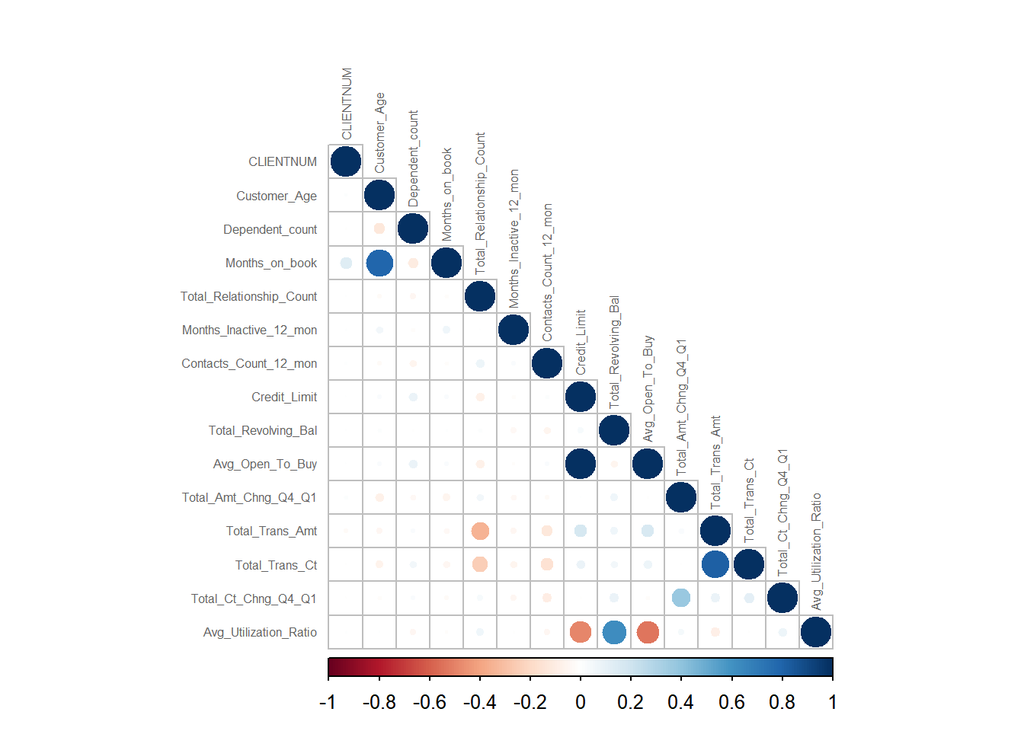

```r
df_num = select_if(df_new,is.numeric)
df_num = data.frame(lapply(df_num, function(x) as.numeric(as.character(x))))
res=cor(df_num)
corrplot(res, type="lower", tl.col="#636363",tl.cex=0.5 )
```

#Avg_Open_To_Buy is highly correlated with Credit_Limit #Total_Trans amount is highly correlated with Total_Trans_Amt #Total_Amt_Chng_Q4_Q1 is correlated with Total_Ct_Cng_Q4_Q1 #Avg_Utilization_Ratio is correlated with Avg_Open_To_BUy, Total_Revolving_Bal and Credit_Limit #months on book is highly co related with customer age.

##correlation of all Categorical variables

```r
dfvar = c("Attrition_Flag","Gender","Education_Level","Marital_Status","Income_Category","Card_Category")
df_var = subset(df_new, select = dfvar)

var <- GKtauDataframe(df_var)
var
```

```
##                 Attrition_Flag Gender Education_Level Marital_Status
## Attrition_Flag           2.000  0.001           0.000          0.000
## Gender                   0.001  2.000           0.000          0.000
## Education_Level          0.002  0.001           6.000          0.001
## Marital_Status           0.001  0.000           0.000          3.000
## Income_Category          0.002  0.689           0.001          0.001
## Card_Category            0.000  0.008           0.000          0.002
##                 Income_Category Card_Category
## Attrition_Flag            0.000         0.000
## Gender                    0.239         0.007
## Education_Level           0.001         0.001
## Marital_Status            0.000         0.002
## Income_Category           5.000         0.007
## Card_Category             0.003         4.000
## attr(,"class")
## [1] "GKtauMatrix"
```

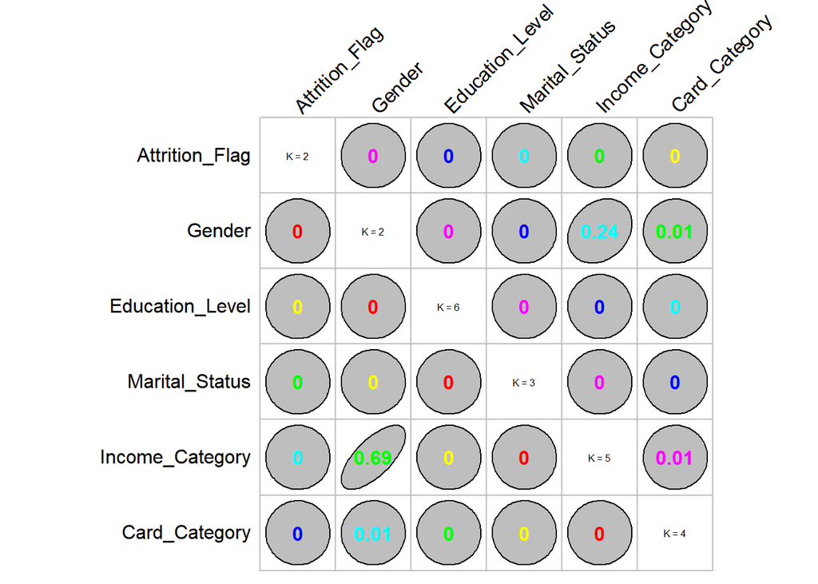

```r
plot(var, diagSize = 0.5)
```

#pivot table

```r
#pivot(df_new,compute = c(mean,median) ,variable = Total_Trans_Amt, c(Gender,Education_Level,Marital_Status,Income_Category,Card_Category))
```

#Dimension Reduction #we feel that the Client nu_mber is not usefull so dropping that Varible

```r
df_new$CLIENTNUM<- NULL
```

#Exploratory Data Analysis of the data after reducing of missing values,Outliers. #The Dependent varible is attrition and rest are the independent varaible.

# converting the charecteristic variable to factors.

```r
df_new$Attrition_Flag <- as.factor(df_new$Attrition_Flag)
df_new$Gender <- as.factor(df_new$Gender)
df_new$Education_Level <- as.factor(df_new$Education_Level)
df_new$Marital_Status <- as.factor(df_new$Marital_Status)
df_new$Income_Category <- as.factor(df_new$Income_Category)
df_new$Card_Category <- as.factor(df_new$Card_Category)
```

# Age vs Attrirition

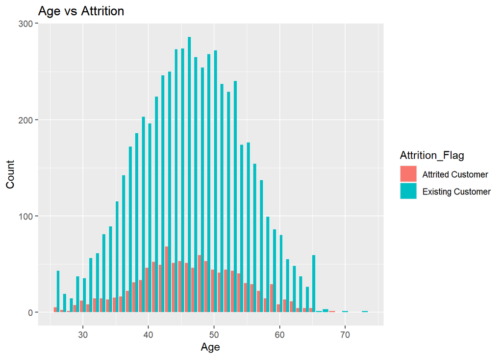

```r
pl1_new <-ggplot(df_new, aes(x = Customer_Age, fill = Attrition_Flag)) + geom_bar(position = position_dodge())+labs(x = "Age", y = "Count", title = "Age vs Attrition")
pl1_new
```

#Gender vs Attrition

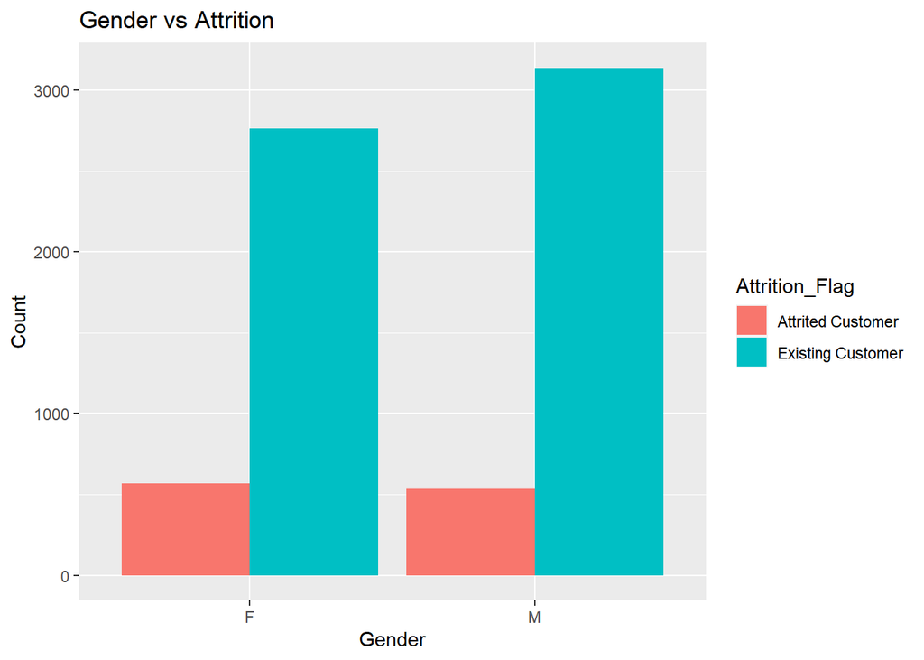

```r
pl2_new <-ggplot(df_new, aes(x = Gender, fill = Attrition_Flag)) + geom_bar(position = position_dodge())+labs(x = "Gender", y = "Count", title = "Gender vs Attrition")
pl2_new
```

#Dependent count vs Attrition

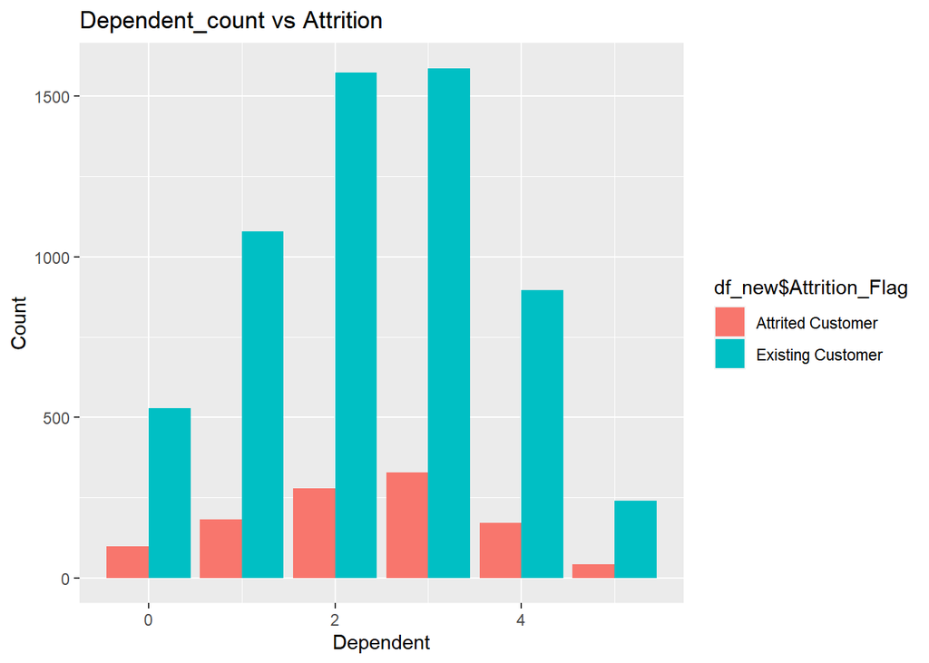

```r
pl3_new <-ggplot(df_new, aes(x = df_new$Dependent_count, fill = df_new$Attrition_Flag)) + geom_bar(position = position_dodge())+labs(x = "Dependent", y = "Count", title = "Dependent_count vs Attrition")
pl3_new
```

#Education vs Attrition

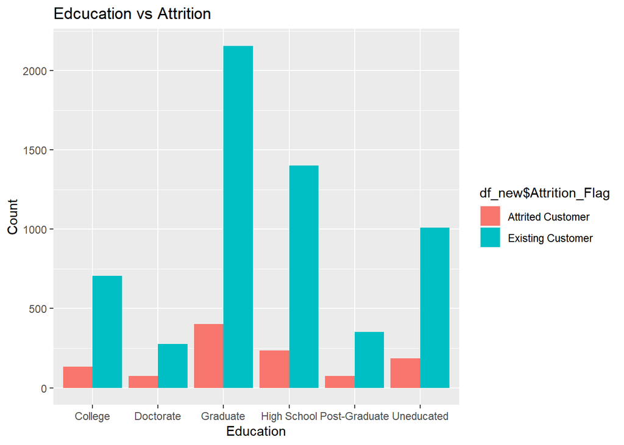

```r
pl4_new <-ggplot(df_new, aes(x = df_new$Education_Level, fill = df_new$Attrition_Flag)) + geom_bar(position = position_dodge())+labs(x = "Education", y = "Count", title = "Edcucation vs Attrition")
pl4_new
```

#Marriage status vs Attrition

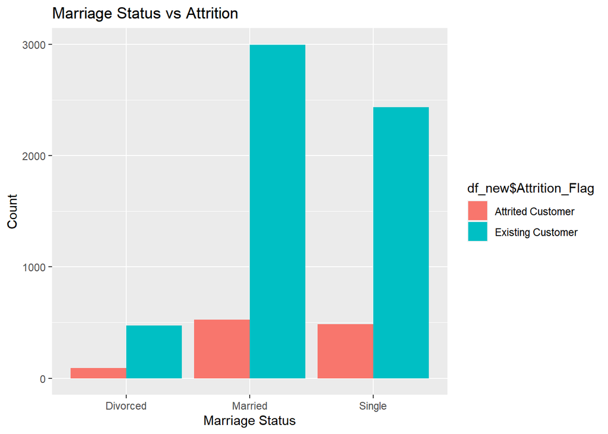

```r
pl5_new <-ggplot(df_new, aes(x = df_new$Marital_Status, fill = df_new$Attrition_Flag)) + geom_bar(position = position_dodge())+labs(x = "Marriage Status", y = "Count", title = "Marriage Status vs Attrition")
pl5_new
```

#Income category vs Attrition

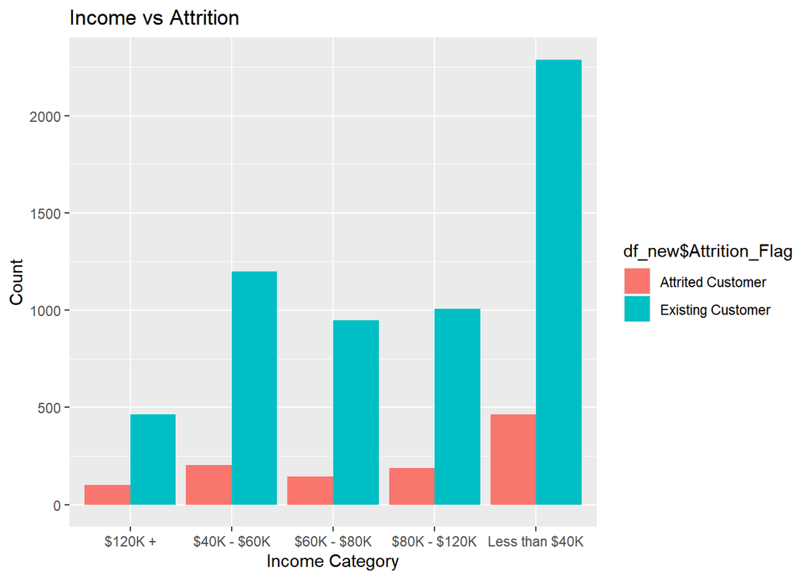

```r
pl6_new <-ggplot(data = df_new,aes(x = df_new$Income_Category, fill = df_new$Attrition_Flag)) +
  geom_bar(position = position_dodge())+labs(x = "Income Category", y = "Count",title = "Income vs Attrition")
pl6_new
```

#Card Vs Attrition

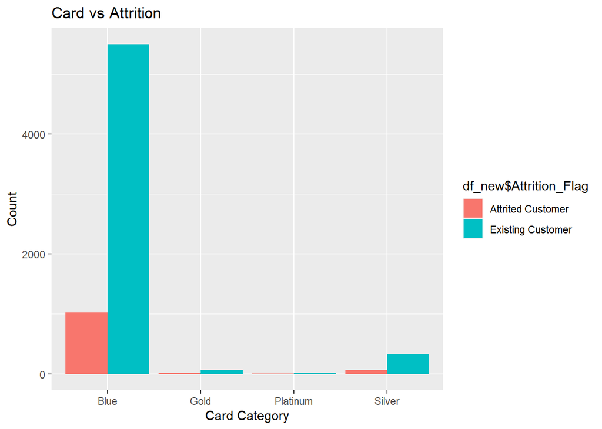

```r
pl7_new <-ggplot(data = df_new,aes(x = df_new$Card_Category, fill = df_new$Attrition_Flag)) +
  geom_bar(position = position_dodge())+labs(x = "Card Category", y = "Count",title = "Card vs Attrition")
pl7_new
```

#Months on Book vs Attrition

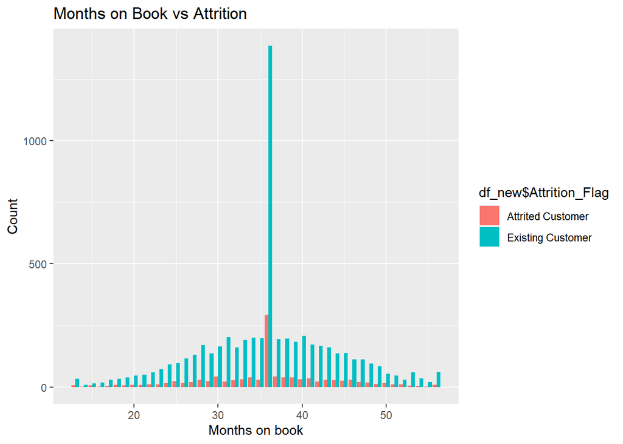

```r
pl8_new <-ggplot(data = df_new,aes(x = df_new$Months_on_book, fill = df_new$Attrition_Flag)) +
  geom_bar(position = position_dodge())+labs(x = "Months on book", y = "Count",title = "Months on Book vs Attrition")
pl8_new
```

#Total Relationship count Vs Attrition

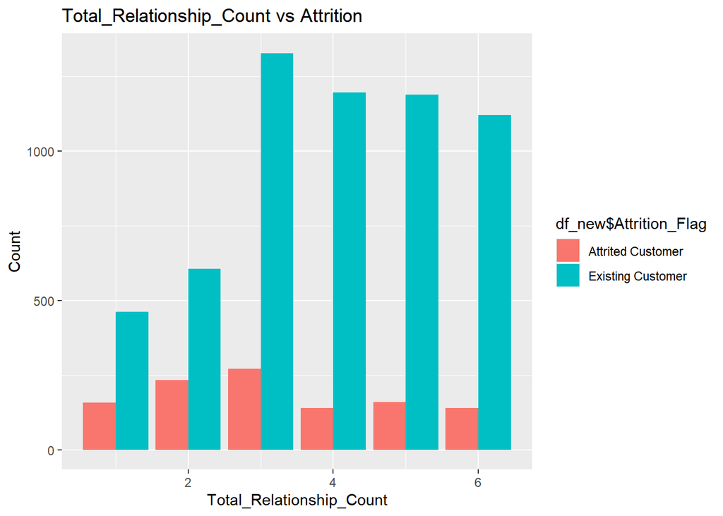

```r
pl9_new <-ggplot(data = df_new,aes(x = df_new$Total_Relationship_Count, fill = df_new$Attrition_Flag)) +
  geom_bar(position = position_dodge())+labs(x = "Total_Relationship_Count", y = "Count",title = "Total_Relationship_Count vs Attrition")
pl9_new
```

#Months inactive in 12 Vs Attrition

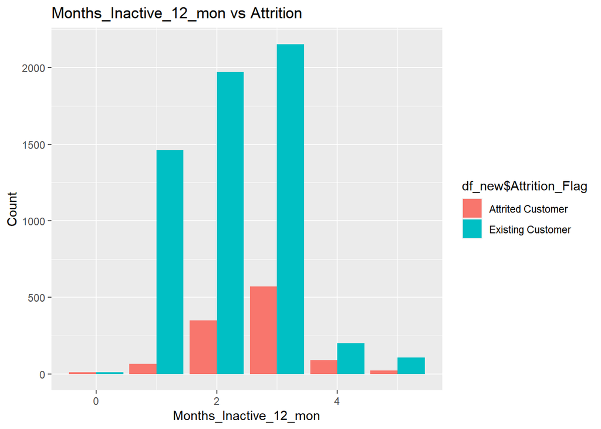

```r
pl10_new <-ggplot(data = df_new,aes(x = df_new$Months_Inactive_12_mon, fill = df_new$Attrition_Flag)) +
  geom_bar(position = position_dodge())+labs(x = "Months_Inactive_12_mon", y = "Count",title = "Months_Inactive_12_mon vs Attrition")
pl10_new
```

#Contact Count vs Attirition

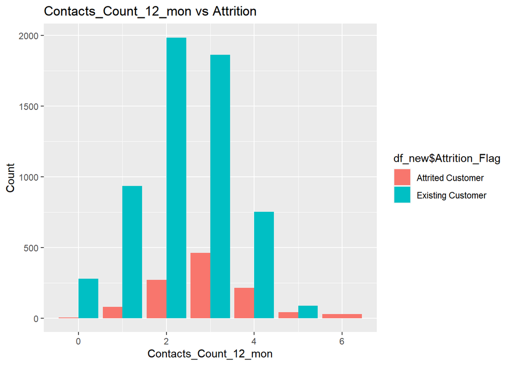

```r
pl11_new <-ggplot(data = df_new,aes(x = df_new$Contacts_Count_12_mon, fill = df_new$Attrition_Flag)) +
  geom_bar(position = position_dodge())+labs(x = "Contacts_Count_12_mon", y = "Count",title = "Contacts_Count_12_mon vs Attrition")
pl11_new
```

#Credit limit Vs Attrition

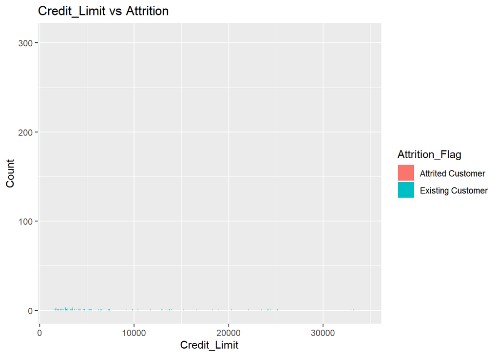

```r
pl12_new <-ggplot(data = df_new,aes(x = Credit_Limit, fill = Attrition_Flag)) +
  geom_bar(position = position_dodge())+labs(x = "Credit_Limit", y = "Count",title = "Credit_Limit vs Attrition")
pl12_new
```

#Total Revolving Balance Vs Attrition

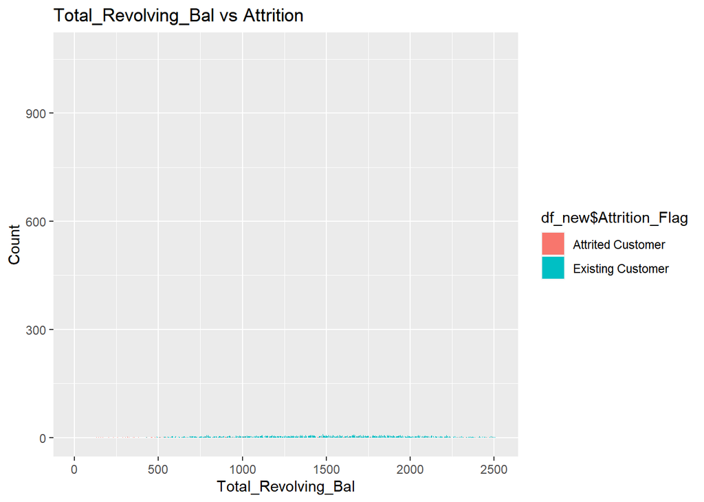

```r
pl13_new <-ggplot(data = df_new,aes(x = df_new$Total_Revolving_Bal, fill = df_new$Attrition_Flag)) +
  geom_bar(position = position_dodge())+labs(x = "Total_Revolving_Bal", y = "Count",title = "Total_Revolving_Bal vs Attrition")
pl13_new
```

#Avg opn to buy Vs Attrition

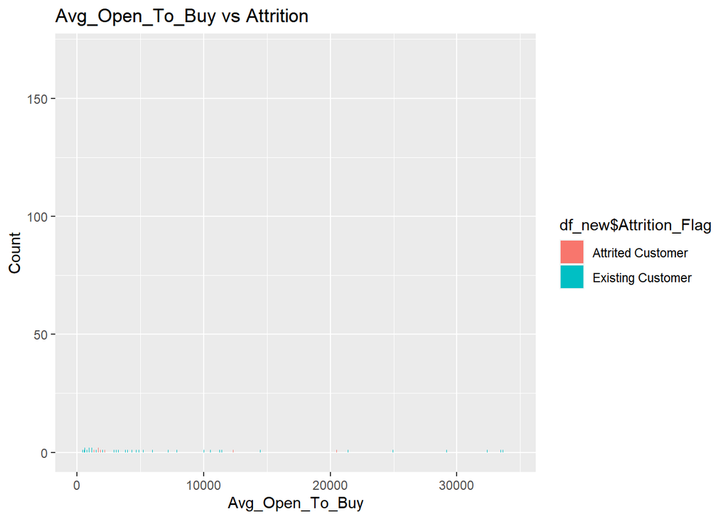

```r
pl14_new <-ggplot(data = df_new,aes(x = df_new$Avg_Open_To_Buy, fill = df_new$Attrition_Flag)) + geom_bar(position = position_dodge())+labs(x = "Avg_Open_To_Buy", y = "Count",title = "Avg_Open_To_Buy vs Attrition")
pl14_new
```

#Total_Trans_Amt Vs Attrition

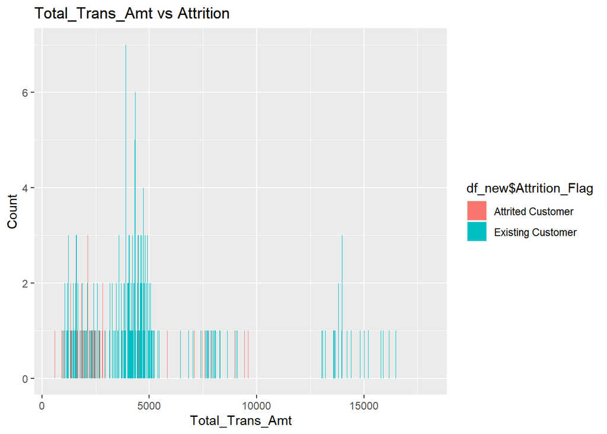

```r
pl15_new <-ggplot(data = df_new,aes(x = df_new$Total_Trans_Amt, fill = df_new$Attrition_Flag)) + geom_bar(position = position_dodge())+labs(x = "Total_Trans_Amt", y = "Count",title = "Total_Trans_Amt vs Attrition")
pl15_new
```

#Total_Trans_Count Vs Attrition

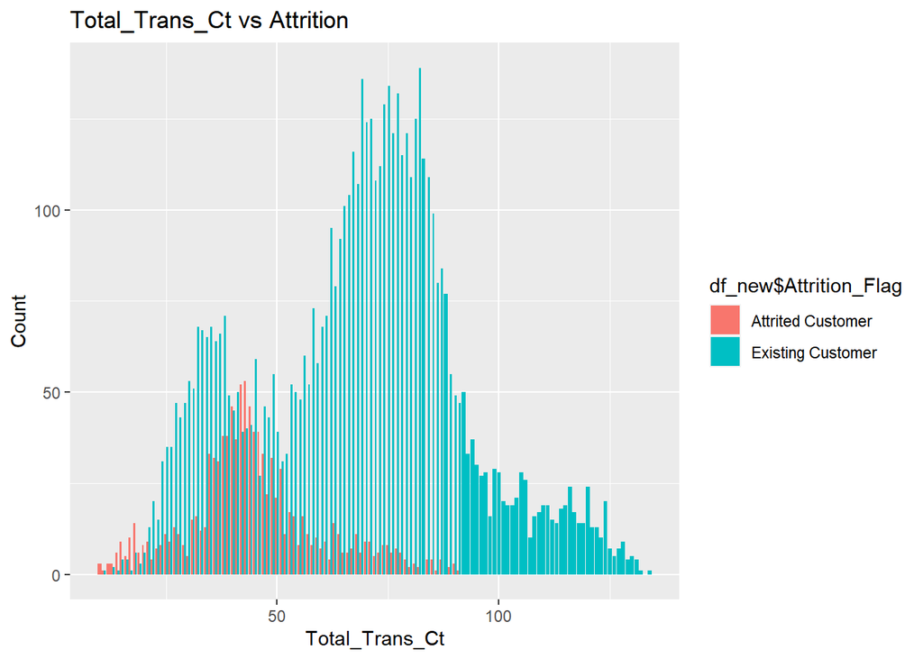

```r
pl16_new <-ggplot(data = df_new,aes(x = df_new$Total_Trans_Ct, fill = df_new$Attrition_Flag)) + geom_bar(position = position_dodge())+labs(x = "Total_Trans_Ct", y = "Count",title = "Total_Trans_Ct vs Attrition")
pl16_new
```

#Avg_Utilization_Ratio Vs Attrition

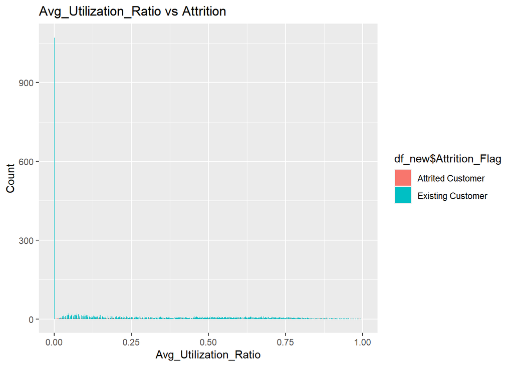

```r
pl17_new <-ggplot(data = df_new,aes(x = df_new$Avg_Utilization_Ratio, fill = df_new$Attrition_Flag)) + geom_bar(position = position_dodge())+labs(x = "Avg_Utilization_Ratio", y = "Count",title = "Avg_Utilization_Ratio vs Attrition")
pl17_new
```

#total Grid of the Vizualizations with the Attrition rate

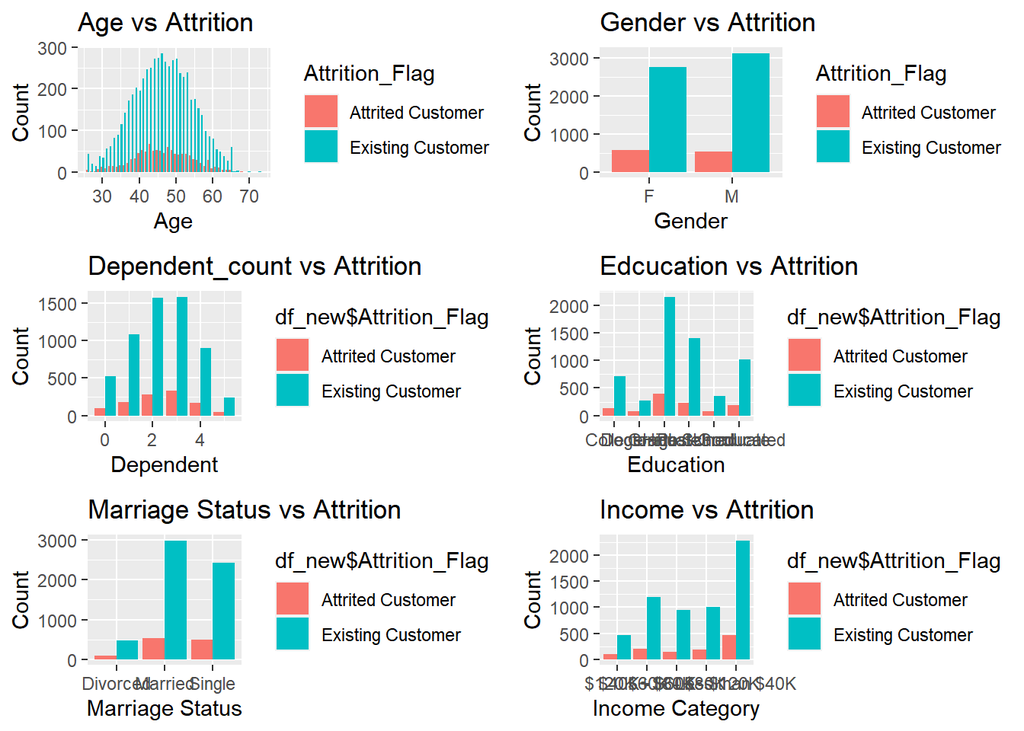

```r
grid.arrange( pl1_new,pl2_new,pl3_new,pl4_new,pl5_new,pl6_new,ncol=2)
```

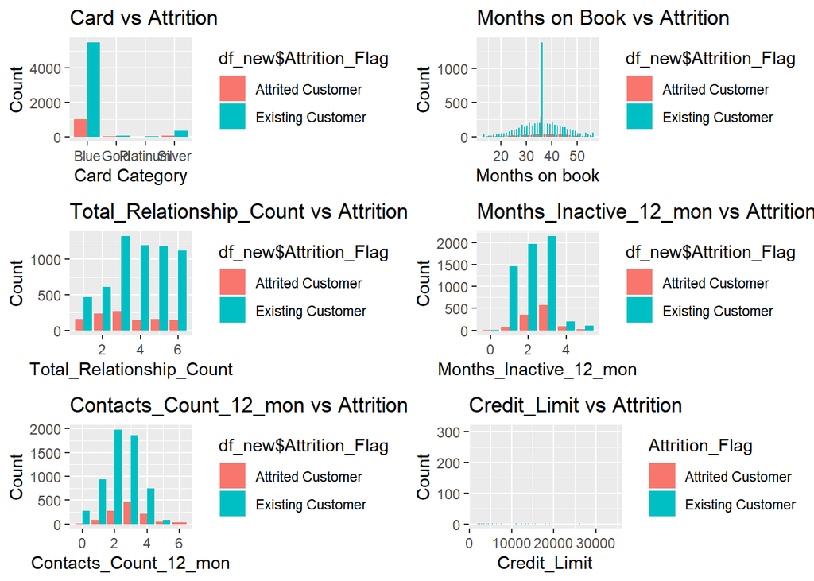

```r
grid.arrange( pl7_new,pl8_new,pl9_new,pl10_new,pl11_new,pl12_new,ncol=2)
```

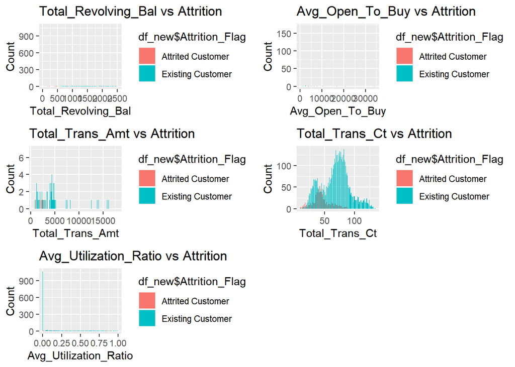

```r
grid.arrange( pl13_new,pl14_new,pl15_new,pl16_new,pl17_new,ncol=2)
```

```r
#install.packages("factoextra")
#install.packages("gains")
#install.packages("e1071")
library(e1071)
library(gains)
library(factoextra)
```

#Months_on_book vs age vs attrition

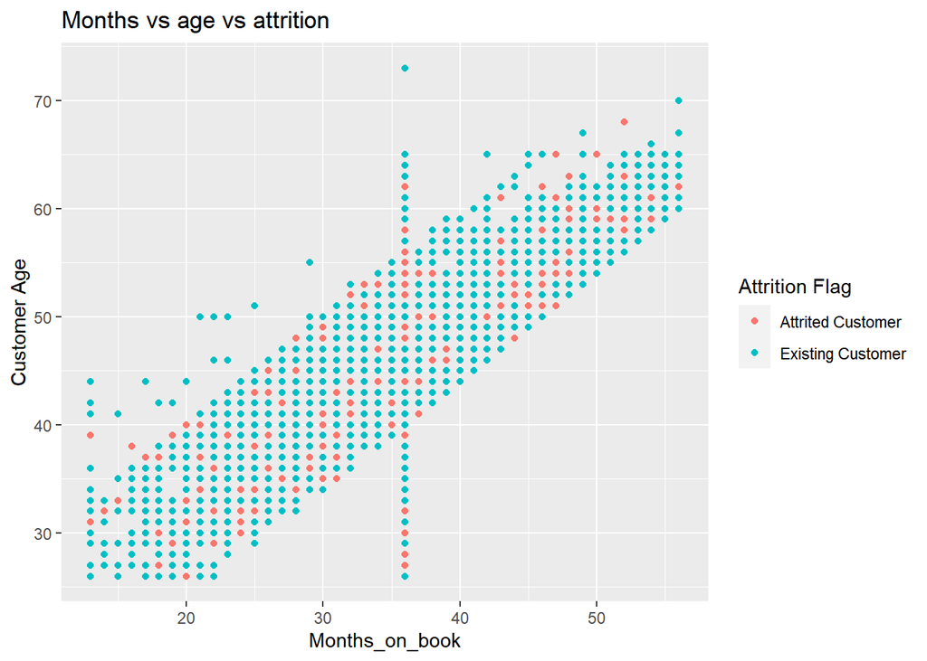

```r
m1<-ggplot(df_new, aes(x = Months_on_book,
                             y = Customer_Age,
                             color=Attrition_Flag)) +
  geom_point() +
  labs(x = "Months_on_book",
       title = "Months vs age vs attrition",
       y = "Customer Age",
       color = "Attrition Flag")

m1
```

#Total_Relationship_Count vs Age vs attrition

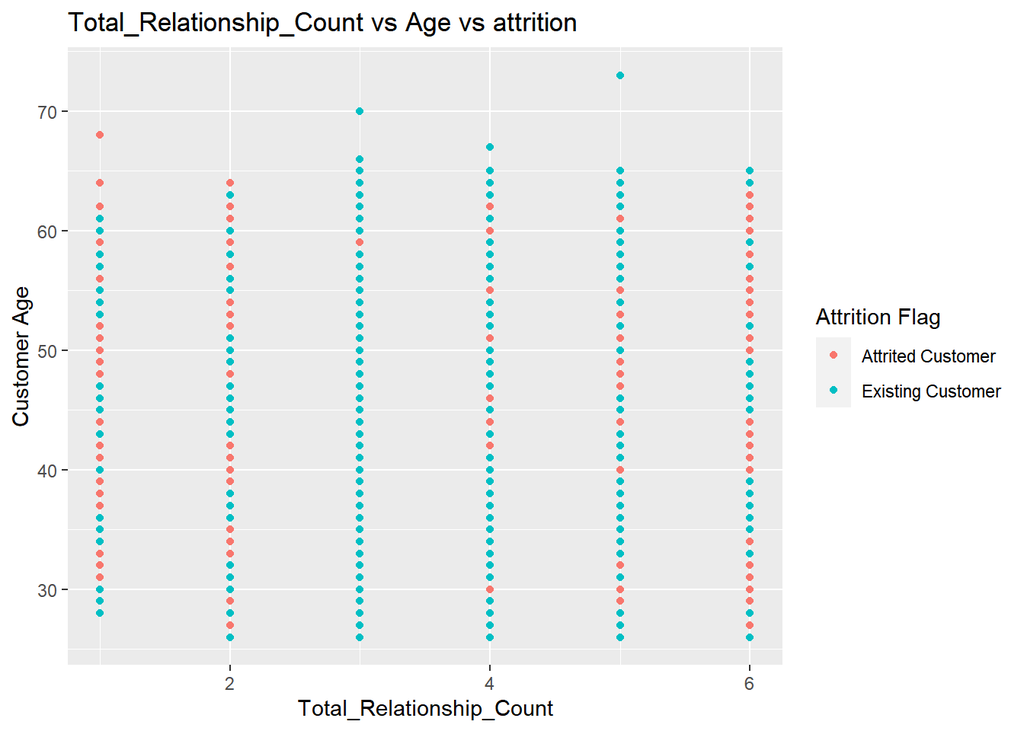

```r
m2<-ggplot(df_new, aes(x = Total_Relationship_Count,
                             y = Customer_Age,
                             color=Attrition_Flag)) +
  geom_point() +
  labs(x = "Total_Relationship_Count",
       title = "Total_Relationship_Count vs Age vs attrition",
       y = "Customer Age",
       color = "Attrition Flag")

m2
```

#Credit limit vs Age vs attrition

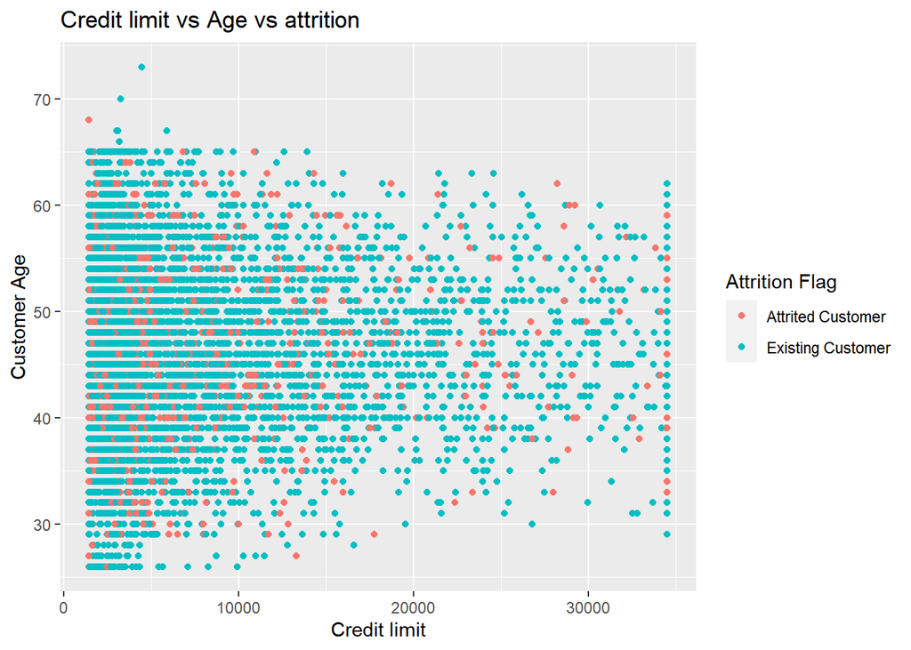

```r
m3<-ggplot(df_new, aes(x = Credit_Limit,
                             y = Customer_Age,
                             color=Attrition_Flag)) +
  geom_point() +
  labs(x = "Credit limit",
       title = "Credit limit vs Age vs attrition",
       y = "Customer Age",
       color = "Attrition Flag")

m3
```

#Total_Revolving_Bal vs Age vs attrition

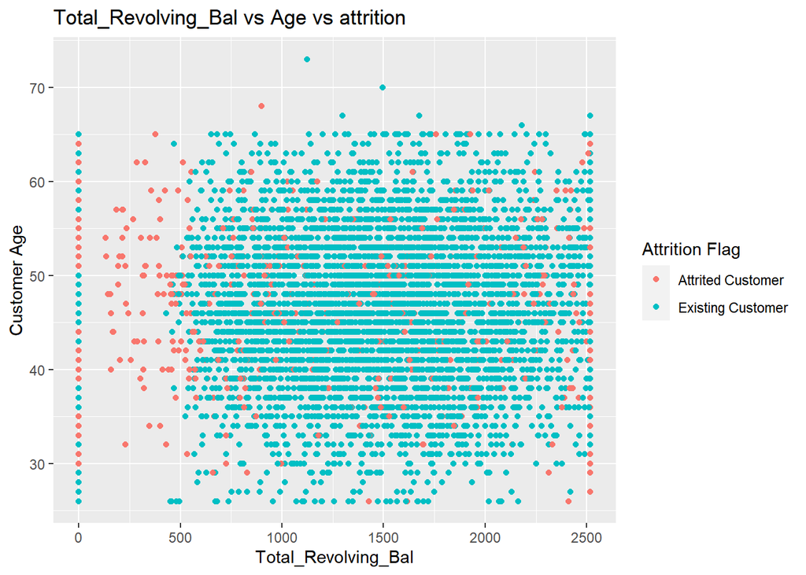

```r
m4<-ggplot(df_new, aes(x = Total_Revolving_Bal,
                             y = Customer_Age,
                             color=Attrition_Flag)) +
  geom_point() +
  labs(x = "Total_Revolving_Bal",
       title = "Total_Revolving_Bal vs Age vs attrition",
       y = "Customer Age",
       color = "Attrition Flag")

m4
```

#Avg_Open_To_Buy vs Age vs attrition

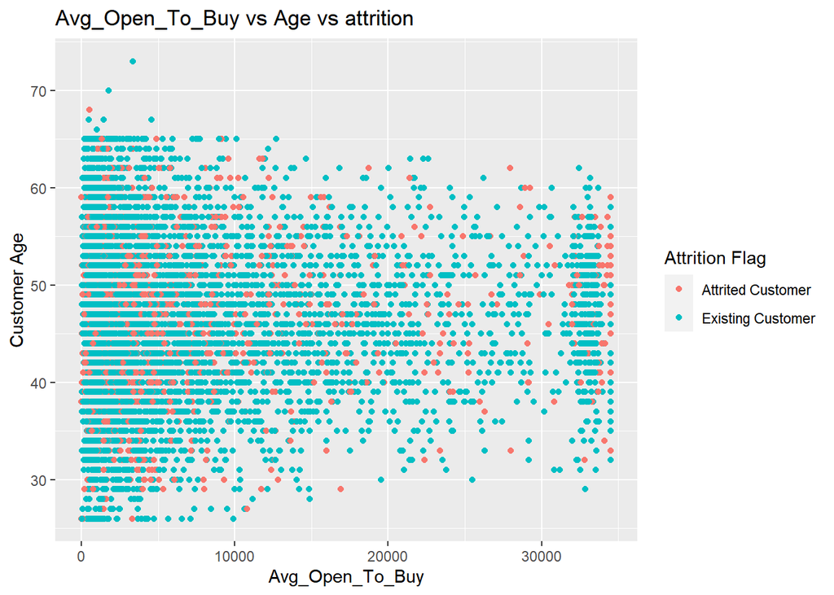

```r
m5<-ggplot(df_new, aes(x = Avg_Open_To_Buy,
                             y = Customer_Age,
                             color=Attrition_Flag)) +
  geom_point() +
  labs(x = "Avg_Open_To_Buy",
       title = "Avg_Open_To_Buy vs Age vs attrition",
       y = "Customer Age",
       color = "Attrition Flag")

m5
```

#Total_Amt_Chng_Q4_Q1 vs Age vs attrition

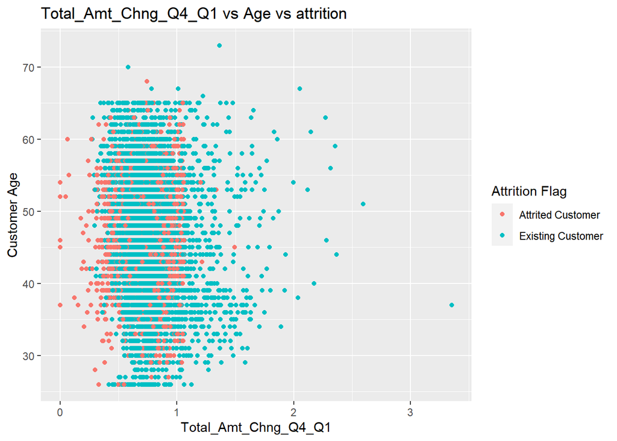

```r
m6<-ggplot(df_new, aes(x = Total_Amt_Chng_Q4_Q1,
                             y = Customer_Age,
                             color=Attrition_Flag)) +
  geom_point() +
  labs(x = "Total_Amt_Chng_Q4_Q1",
       title = "Total_Amt_Chng_Q4_Q1 vs Age vs attrition",
       y = "Customer Age",
       color = "Attrition Flag")

m6
```

#Total_Trans_Amt vs Age vs attrition

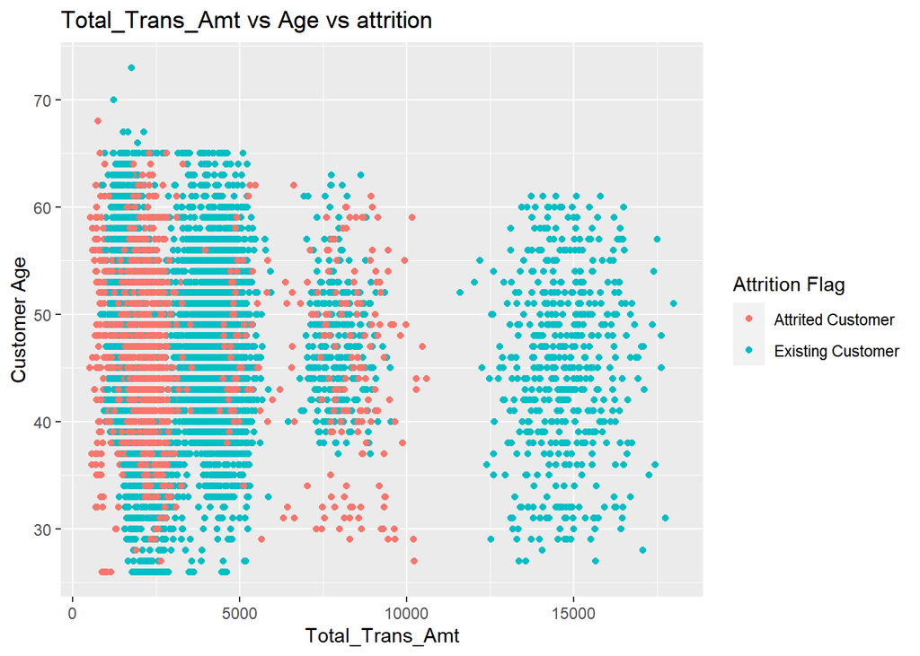

```r
m7<-ggplot(df_new, aes(x = Total_Trans_Amt,
                             y = Customer_Age,
                             color=Attrition_Flag)) +
  geom_point() +
  labs(x = "Total_Trans_Amt",
       title = "Total_Trans_Amt vs Age vs attrition",
       y = "Customer Age",
       color = "Attrition Flag")

m7
```

#Total_Trans_Ct vs Age vs attrition

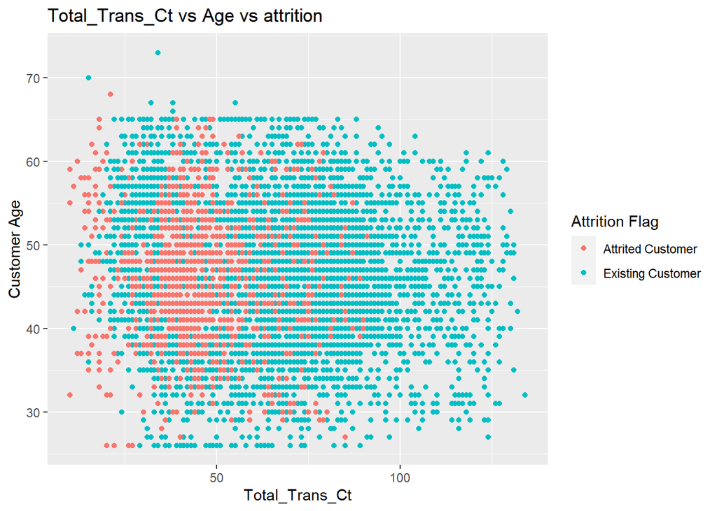

```r
m8<-ggplot(df_new, aes(x = Total_Trans_Ct,
                             y = Customer_Age,
                             color=Attrition_Flag)) +
  geom_point() +
  labs(x = "Total_Trans_Ct",
       title = "Total_Trans_Ct vs Age vs attrition",
       y = "Customer Age",
       color = "Attrition Flag")

m8
```

#Avg_Utilization_Ratio vs Age vs attrition

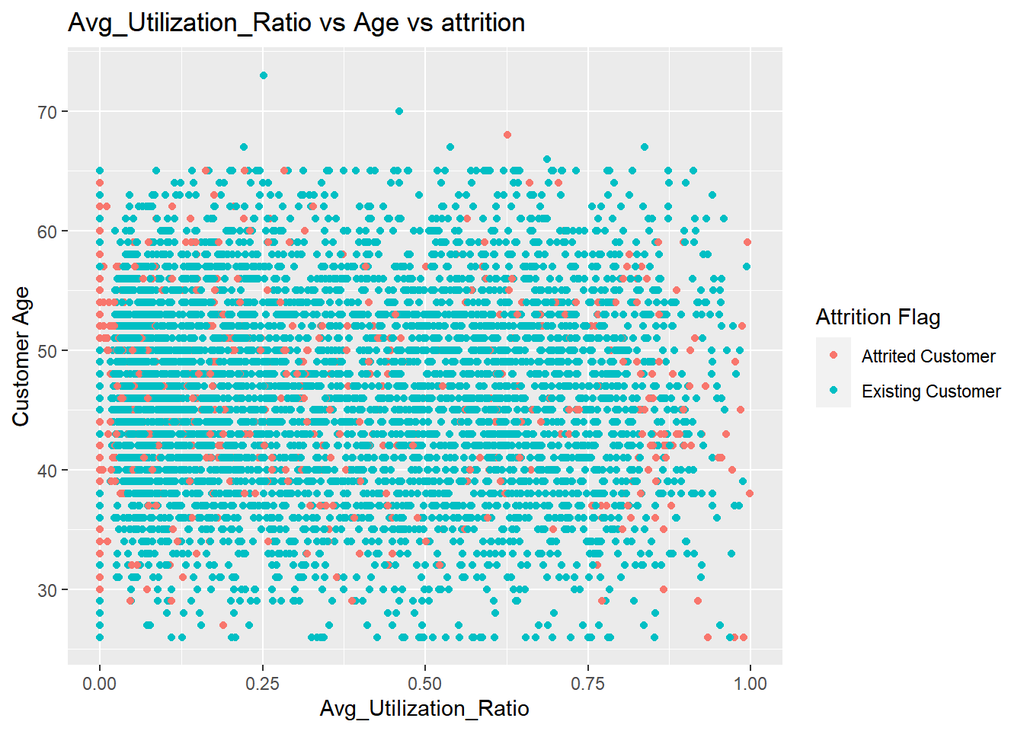

```r
m9<-ggplot(df_new, aes(x = Avg_Utilization_Ratio,
                             y = Customer_Age,
                             color=Attrition_Flag)) +
  geom_point() +
  labs(x = "Avg_Utilization_Ratio",
       title = "Avg_Utilization_Ratio vs Age vs attrition",
       y = "Customer Age",
       color = "Attrition Flag")

m9
```

#Partition of Data.

```r
set.seed(2)
train.index <- sample(c(1:dim(df_new)[1]), dim(df_new)[1]*0.6)
train.df <- df_new[train.index, ]
valid.df <- df_new[-train.index, ]
```

#PCA Analysis for numerical

```r
pcs <- prcomp(na.omit(train.df[,-c(1:8)]),scale. = T)
summary(pcs)
```

```
## Importance of components:
##                           PC1    PC2    PC3    PC4     PC5    PC6     PC7
## Standard deviation     1.6182 1.4136 1.1833 1.1300 1.02423 0.9798 0.95114
## Proportion of Variance 0.2182 0.1665 0.1167 0.1064 0.08742 0.0800 0.07539
## Cumulative Proportion  0.2182 0.3847 0.5014 0.6078 0.69524 0.7752 0.85063
##                            PC8     PC9    PC10    PC11                PC12
## Standard deviation     0.89081 0.78441 0.47050 0.40282 0.00000000000000136
## Proportion of Variance 0.06613 0.05128 0.01845 0.01352 0.00000000000000000
## Cumulative Proportion  0.91675 0.96803 0.98648 1.00000 1.00000000000000000
```

#Data Developing for Predictive model

```r
table(train.df$Attrition_Flag)
```

```
##
## Attrited Customer Existing Customer
##               650              3553
```

```r
prop.table(table(train.df$Attrition_Flag))
```

```
##
## Attrited Customer Existing Customer
##         0.1546514         0.8453486
```